# Salary & Compensation Trends

Author

Nutchanon Chaiyaratana

Published

June 4, 2026

Modified

June 4, 2026

## Overview

This section analyzes salary and compensation patterns in 2024 job postings using the Lightcast dataset. The goal is to understand how salaries vary across occupations, industries, locations, employment types, remote work arrangements, and AI-related skills.

Because salary information is not available for every job posting, this analysis focuses on records with valid salary values greater than zero when comparing salary outcomes.

## Step 1: Load Data and Create Relational Tables

This section analyzes salary and compensation patterns in 2024 job postings using the Lightcast dataset. The goal is to understand how salaries vary across occupations, industries, locations, employment types, and remote work arrangements.

Because salary information is not available for every job posting, this analysis focuses on records with valid salary values greater than zero.

```python
# load data + create tables here
from pyspark.sql import SparkSession
from pyspark.sql.functions import col, monotonically_increasing_id

spark = SparkSession.builder \
    .config("spark.driver.host", "localhost") \
    .appName("SalaryCompensationTrends") \
    .getOrCreate()

spark.catalog.clearCache()

df = spark.read.option("header", "true") \
    .option("inferSchema", "true") \
    .option("multiLine", "true") \
    .option("escape", "\"") \
    .csv("data/lightcast_job_postings.csv")

df.createOrReplaceTempView("raw_jobs")
# Basic cleaning: remove records without a job posting ID

df_clean = df.filter(col("ID").isNotNull())

df_clean.createOrReplaceTempView("raw_jobs")

print("Original rows:", df.count())

print("Rows after removing missing ID:", df_clean.count())

# companies table
companies_df = df_clean.select(
    col("COMPANY").alias("company_id"),
    col("COMPANY").alias("company"),
    col("COMPANY_NAME").alias("company_name"),
    col("COMPANY_RAW").alias("company_raw"),
    col("COMPANY_IS_STAFFING").alias("company_is_staffing")
).dropDuplicates(["company_id"])

companies_df.createOrReplaceTempView("companies")

# industries table
industries_df = df_clean.select(
    col("NAICS_2022_6").alias("naics_2022_6"),
    col("NAICS_2022_6_NAME").alias("naics_2022_6_name")
).dropDuplicates()

industries_df = industries_df.withColumn(
    "industry_id",
    monotonically_increasing_id()
)

industries_df = industries_df.select(
    "industry_id",
    "naics_2022_6",
    "naics_2022_6_name"
)

industries_df.createOrReplaceTempView("industries")

# locations table
locations_df = df_clean.select(
    col("LOCATION").alias("location"),
    col("CITY_NAME").alias("city_name"),
    col("STATE_NAME").alias("state_name"),
    col("COUNTY_NAME").alias("county_name"),
    col("MSA").alias("msa"),
    col("MSA_NAME").alias("msa_name")
).dropDuplicates()

locations_df = locations_df.withColumn(
    "location_id",
    monotonically_increasing_id()
)

locations_df = locations_df.select(
    "location_id",
    "location",
    "city_name",
    "state_name",
    "county_name",
    "msa",
    "msa_name"
)

locations_df.createOrReplaceTempView("locations")

# occupations table
occupations_df = df_clean.select(
    col("SOC_5").alias("soc_5"),
    col("SOC_5_NAME").alias("soc_5_name"),
    col("LOT_SPECIALIZED_OCCUPATION").alias("specialized_occupation"),
    col("LOT_SPECIALIZED_OCCUPATION_NAME").alias("specialized_occupation_name"),
    col("LOT_OCCUPATION_GROUP").alias("occupation_group"),
    col("LOT_OCCUPATION_GROUP_NAME").alias("occupation_group_name")
).dropDuplicates()

occupations_df = occupations_df.withColumn(
    "occupation_id",
    monotonically_increasing_id()
)

occupations_df = occupations_df.select(
    "occupation_id",
    "soc_5",
    "soc_5_name",
    "specialized_occupation",
    "specialized_occupation_name",
    "occupation_group",
    "occupation_group_name"
)

occupations_df.createOrReplaceTempView("occupations")

# job postings table
job_with_industry = df_clean.join(
    industries_df,
    (
        (df["NAICS_2022_6"] == industries_df["naics_2022_6"]) &
        (df["NAICS_2022_6_NAME"] == industries_df["naics_2022_6_name"])
    ),
    "left"
)

job_with_location = job_with_industry.join(
    locations_df,
    (
        (job_with_industry["LOCATION"] == locations_df["location"]) &
        (job_with_industry["CITY_NAME"] == locations_df["city_name"]) &
        (job_with_industry["STATE_NAME"] == locations_df["state_name"]) &
        (job_with_industry["COUNTY_NAME"] == locations_df["county_name"]) &
        (job_with_industry["MSA"] == locations_df["msa"]) &
        (job_with_industry["MSA_NAME"] == locations_df["msa_name"])
    ),
    "left"
)

job_with_keys = job_with_location.join(
    occupations_df,
    (
        (job_with_location["SOC_5"] == occupations_df["soc_5"]) &
        (job_with_location["SOC_5_NAME"] == occupations_df["soc_5_name"]) &
        (job_with_location["LOT_SPECIALIZED_OCCUPATION"] == occupations_df["specialized_occupation"]) &
        (job_with_location["LOT_SPECIALIZED_OCCUPATION_NAME"] == occupations_df["specialized_occupation_name"]) &
        (job_with_location["LOT_OCCUPATION_GROUP"] == occupations_df["occupation_group"]) &
        (job_with_location["LOT_OCCUPATION_GROUP_NAME"] == occupations_df["occupation_group_name"])
    ),
    "left"
)

job_postings_df = job_with_keys.select(
    job_with_keys["ID"].alias("id"),
    job_with_keys["TITLE_CLEAN"].alias("title_clean"),
    job_with_keys["COMPANY"].alias("company_id"),
    col("industry_id"),
    col("occupation_id"),
    job_with_keys["EMPLOYMENT_TYPE_NAME"].alias("employment_type_name"),
    job_with_keys["REMOTE_TYPE_NAME"].alias("remote_type_name"),
    job_with_keys["BODY"].alias("body"),
    job_with_keys["MIN_YEARS_EXPERIENCE"].alias("min_years_experience"),
    job_with_keys["MAX_YEARS_EXPERIENCE"].alias("max_years_experience"),
    job_with_keys["SALARY"].alias("salary"),
    job_with_keys["SALARY_FROM"].alias("salary_from"),
    job_with_keys["SALARY_TO"].alias("salary_to"),
    col("location_id"),
    job_with_keys["POSTED"].alias("posted"),
    job_with_keys["EXPIRED"].alias("expired"),
    job_with_keys["DURATION"].alias("duration")
).filter(
    col("id").isNotNull()
).dropDuplicates(["id"])
job_postings_df.createOrReplaceTempView("job_postings")
```

## Skill Table

```python
from pyspark.sql.functions import split, explode, trim, lit, monotonically_increasing_id, regexp_replace, col

def create_skill_matches(column_name, skill_type):
    return df_clean.select(
        col("ID").alias("job_id"),
        explode(split(col(column_name), ",")).alias("skill_name")
    ).withColumn(
        "skill_name",
        regexp_replace(col("skill_name"), r'[\[\]"]', "")
    ).withColumn(
        "skill_name",
        trim(col("skill_name"))
    ).withColumn(
        "skill_type",
        lit(skill_type)
    ).filter(
        col("skill_name").isNotNull() & (col("skill_name") != "")
    )

specialized_skill_matches = create_skill_matches(
    "SPECIALIZED_SKILLS_NAME",
    "specialized"
)

common_skill_matches = create_skill_matches(
    "COMMON_SKILLS_NAME",
    "common"
)

software_skill_matches = create_skill_matches(
    "SOFTWARE_SKILLS_NAME",
    "software"
)

certification_matches = create_skill_matches(
    "CERTIFICATIONS_NAME",
    "certification"
)

job_skill_matches_raw = specialized_skill_matches.unionByName(
    common_skill_matches
).unionByName(
    software_skill_matches
).unionByName(
    certification_matches
).dropDuplicates(["job_id", "skill_name", "skill_type"])

skills_df = job_skill_matches_raw.select(
    "skill_name",
    "skill_type"
).dropDuplicates()

skills_df = skills_df.withColumn(
    "skill_id",
    monotonically_increasing_id()
)

skills_df = skills_df.select(
    "skill_id",
    "skill_name",
    "skill_type"
)

skills_df.createOrReplaceTempView("skills")

job_skill_matches_df = job_skill_matches_raw.join(
    skills_df,
    on=["skill_name", "skill_type"],
    how="left"
).select(
    "job_id",
    "skill_id",
    "skill_name",
    "skill_type"
)

job_skill_matches_df.createOrReplaceTempView("job_skill_matches")
```

### Validate Registered SQL Tables

Before running the salary analysis queries, I validate that all relational tables were created and registered in Spark SQL.

```python
def style_table(df, format_dict=None):

    styled = df.style

    if format_dict is not None:

        styled = styled.format(format_dict)

    styled = styled.set_properties(**{

        "text-align": "left",

        "white-space": "normal",

        "border": "1px solid black"

    }).set_table_styles([

        {

            "selector": "th",

            "props": [

                ("border", "1px solid black"),

                ("text-align", "left"),

                ("background-color", "#f2f2f2")

            ]

        },

        {

            "selector": "td",

            "props": [

                ("border", "1px solid black"),

                ("padding", "6px")

            ]

        },

        {

            "selector": "table",

            "props": [

                ("border-collapse", "collapse")

            ]

        }

    ])

    return styled
```

```python
table_counts = spark.sql("""
SELECT 'job_postings' AS table_name, COUNT(*) AS row_count FROM job_postings
UNION ALL
SELECT 'companies' AS table_name, COUNT(*) AS row_count FROM companies
UNION ALL
SELECT 'industries' AS table_name, COUNT(*) AS row_count FROM industries
UNION ALL
SELECT 'locations' AS table_name, COUNT(*) AS row_count FROM locations
UNION ALL
SELECT 'occupations' AS table_name, COUNT(*) AS row_count FROM occupations
UNION ALL
SELECT 'skills' AS table_name, COUNT(*) AS row_count FROM skills
UNION ALL
SELECT 'job_skill_matches' AS table_name, COUNT(*) AS row_count FROM job_skill_matches
""")

table_counts_pd = table_counts.toPandas()

style_table(table_counts_pd, {
    "row_count": "{:,.0f}"
})
```

|  | table_name | row_count |
| --- | --- | --- |
| 0 | job_postings | 72,476 |
| 1 | companies | 12,303 |
| 2 | industries | 815 |
| 3 | locations | 5,174 |
| 4 | occupations | 12 |
| 5 | skills | 17,225 |
| 6 | job_skill_matches | 2,004,844 |

### Preview Companies Table

```python
companies_preview = companies_df.select(
    "company_id",
    "company",
    "company_name",
    "company_raw",
    "company_is_staffing"
).limit(5).toPandas()

style_table(companies_preview)
```

|  | company_id | company | company_name | company_raw | company_is_staffing |
| --- | --- | --- | --- | --- | --- |
| 0 | nan | nan | nan | nan | None |
| 1 | 0.000000 | 0.000000 | Unclassified | Unknown | False |
| 2 | 12.000000 | 12.000000 | Adecco | Unknown | True |
| 3 | 20.000000 | 20.000000 | Amazon | Amazon | False |
| 4 | 42.000000 | 42.000000 | Johnson & Johnson | Johnson & Johnson | False |

### Preview Industries Table

```python
industries_preview = industries_df.select(
    "industry_id",
    "naics_2022_6",
    "naics_2022_6_name"
).limit(5).toPandas()

style_table(industries_preview)
```

|  | industry_id | naics_2022_6 | naics_2022_6_name |
| --- | --- | --- | --- |
| 0 | 0 | 311351 | Chocolate and Confectionery Manufacturing from Cacao Beans |
| 1 | 1 | 483211 | Inland Water Freight Transportation |
| 2 | 2 | 813319 | Other Social Advocacy Organizations |
| 3 | 3 | 561510 | Travel Agencies |
| 4 | 4 | 621910 | Ambulance Services |

### Preview Locations Table

```python
locations_preview = locations_df.select(
    "location_id",
    "city_name",
    "state_name",
    "county_name",
    "msa",
    "msa_name"
).limit(5).toPandas()

style_table(locations_preview)
```

|  | location_id | city_name | state_name | county_name | msa | msa_name |
| --- | --- | --- | --- | --- | --- | --- |
| 0 | 0 | Cary, NC | North Carolina | Wake, NC | 39580 | Raleigh-Cary, NC |
| 1 | 1 | Tallassee, AL | Alabama | Elmore, AL | 33860 | Montgomery, AL |
| 2 | 2 | Columbus, OH | Ohio | Franklin, OH | 18140 | Columbus, OH |
| 3 | 3 | Little River, SC | South Carolina | Horry, SC | 34820 | Myrtle Beach-Conway-North Myrtle Beach, SC-NC |
| 4 | 4 | Bowling Green, KY | Kentucky | Warren, KY | 14540 | Bowling Green, KY |

### Preview Occupations Table

```python
occupations_preview = occupations_df.select(
    "occupation_id",
    "soc_5",
    "soc_5_name",
    "specialized_occupation",
    "specialized_occupation_name",
    "occupation_group",
    "occupation_group_name"
).limit(5).toPandas()

style_table(occupations_preview)
```

|  | occupation_id | soc_5 | soc_5_name | specialized_occupation | specialized_occupation_name | occupation_group | occupation_group_name |
| --- | --- | --- | --- | --- | --- | --- | --- |
| 0 | 0 | 15-2051 | Data Scientists | 20221013 | Healthcare Analyst | 2022 | Health IT Professionals |
| 1 | 1 | 15-2051 | Data Scientists | 23101010 | Business Intelligence Analyst | 2310 | Business Intelligence |
| 2 | 2 | 15-2051 | Data Scientists | 11111012 | Business Analyst (General) | 1111 | Business Analysis |
| 3 | 3 | 15-2051 | Data Scientists | 23111311 | Data Quality Analyst | 2311 | Data Analysis and Mathematics |
| 4 | 4 | 15-2051 | Data Scientists | 23111310 | Data Analyst | 2311 | Data Analysis and Mathematics |

### Preview Job Postings Table

```python
job_postings_preview = job_postings_df.select(
    "id",
    "title_clean",
    "company_id",
    "industry_id",
    "occupation_id",
    "location_id",
    "salary",
    "posted"
).limit(5).toPandas()

style_table(job_postings_preview)
```

|  | id | title_clean | company_id | industry_id | occupation_id | location_id | salary | posted |
| --- | --- | --- | --- | --- | --- | --- | --- | --- |
| 0 | 00006f1700b862ca01a347e70d7f251249254955 | cfsa system tester entry | 38874575 | 547 | 2 | 174 | nan | 9/4/2024 |
| 1 | 0002112a13c771f03ba68a72a3f9f59c84c4c376 | data analyst on site hybrid | 38266460 | 143 | 4 | 4404 | nan | 6/20/2024 |
| 2 | 0002da053ec8dcb9cc39a12248d845d13e071da6 | senior business analyst healthcare | 11402410 | 198 | 0 | 257 | nan | 9/25/2024 |
| 3 | 0003189dd6559dbc6cfed514f81a7581be3b7b79 | data analyst | 99500729 | 500 | 4 | 3456 | nan | 7/2/2024 |
| 4 | 000749dd4ff897bf07a61b1b1d83593a67de09ac | data analyst | 43148341 | 321 | 4 | 480 | nan | 9/13/2024 |

### Preview Skills Table

```python
skills_preview = skills_df.select(
    "skill_id",
    "skill_name",
    "skill_type"
).limit(10).toPandas()

style_table(skills_preview)
```

|  | skill_id | skill_name | skill_type |
| --- | --- | --- | --- |
| 0 | 0 | Data Architecture | specialized |
| 1 | 1 | Fixed Asset | specialized |
| 2 | 2 | Project Portfolio Management | specialized |
| 3 | 3 | Internal Reporting | specialized |
| 4 | 4 | Computer Systems | specialized |
| 5 | 5 | Data Distribution Services | specialized |
| 6 | 6 | Spotfire (Data Analytics Software) | specialized |
| 7 | 7 | Spring MVC | specialized |
| 8 | 8 | Microsoft 365 | specialized |
| 9 | 9 | Database Security | specialized |

### Preview Job Skill Matches Table

```python
job_skill_matches_preview = job_skill_matches_df.select(
    "job_id",
    "skill_id",
    "skill_name",
    "skill_type"
).limit(10).toPandas()

style_table(job_skill_matches_preview)
```

|  | job_id | skill_id | skill_name | skill_type |
| --- | --- | --- | --- | --- |
| 0 | 3ab12db3af482b82f78111a96b015cdff6b3923f | 630 | Finance | specialized |
| 1 | 8b7196b4a4fbb9609519f5c51e3dcee386f23471 | 1080 | SQL (Programming Language) | specialized |
| 2 | 06d6f7a2c9e32d55ef167e6fd4cf0ba891436840 | 2032 | Industry Standards | specialized |
| 3 | 0180b1cda39b3d25b2a93b7a2a84de109201d45c | 2420 | Business Analysis | specialized |
| 4 | 851e00080060af7b4307b5b547eed0a8f796547c | 3110 | Billing | specialized |
| 5 | 3d589c9d84677ca9468a5bc82295456e0ce6b13f | 6244 | Data Integrity | specialized |
| 6 | 82c856a0d726efeca04bce82aeebbaea747a6f51 | 7094 | Deposit Accounts | specialized |
| 7 | 35d421d20c59b9c664d38f461ed5700b05714fb2 | 7792 | Root Cause Analysis | specialized |
| 8 | 6396d0f5e8c9feaa0d2a8e13c0c0ab55da4eb05c | 8388 | Technological Change | specialized |
| 9 | 799924ec2f2bf4f2e48ba5f10929a3e312446f12 | 10855 | Test Planning | specialized |

## Salary & Compensation Trends

### Explore Career Categories and Sample Job Titles

Before classifying postings as AI-related or non-AI, I first review the career categories and sample job titles in the dataset.

```python
career_title_preview = spark.sql("""
SELECT
    o.specialized_occupation_name,
    COUNT(j.id) AS job_count,
    COUNT(DISTINCT j.title_clean) AS unique_job_titles,
    CONCAT_WS(', ', SLICE(COLLECT_SET(j.title_clean), 1, 10)) AS sample_titles
FROM job_postings j
LEFT JOIN occupations o
    ON j.occupation_id = o.occupation_id
WHERE
    o.specialized_occupation_name IS NOT NULL
    AND j.title_clean IS NOT NULL
GROUP BY
    o.specialized_occupation_name
ORDER BY
    job_count DESC
""")

career_title_preview_pd = career_title_preview.toPandas()

style_table(career_title_preview_pd, {
    "job_count": "{:,.0f}",
    "unique_job_titles": "{:,.0f}"
})
```

|  | specialized_occupation_name | job_count | unique_job_titles | sample_titles |
| --- | --- | --- | --- | --- |
| 0 | Data Analyst | 27,814 | 8,544 | commercial commissions data analyst, metadata lead mn, senior data analyst hybrid or remote, data curator, corporate functions lead data management analyst, transit data analyst, environmental data va… |
| 1 | General ERP Analyst / Consultant | 9,926 | 4,044 | sr sap s hana consultant, sap p p ariba consultant onsite texas local, mainframe enterprise analyst, enterprise sales consultant, programmer analyst enterprise data services, sap sd mm w ewm consultan… |
| 2 | Enterprise Architect | 8,209 | 2,717 | staff solution architect, cloud enterprise architect google cloud platform, security framework architect, enterprise application architect corporate solutions, enterprise java architect, unqork archit… |
| 3 | Oracle Consultant / Analyst | 8,129 | 3,336 | ft pt office admin for family owned automotive distributor, oracle otc o c consultant order to cash, team lead assistant manager, functional oracle fusion cash management consultant, oracle developer … |
| 4 | SAP Analyst / Admin | 7,715 | 4,162 | everpro salesforce solutions consultant ii remote us, drug rebate analyst on site, direct care professional pm to pm shift calling experienced caregiving experts, sap business partner warehouse and ma… |
| 5 | Business Analyst (General) | 4,294 | 2,277 | student intern, intern business transformation, business process risk identification process engineer, solutions specialist engineering services, support analyst bsc, cloud itsm analyst, associate pri… |
| 6 | Business Intelligence Analyst | 3,636 | 1,125 | business intelligence analyst sql server, lean change agent, sr reporting technician, business intelligence analyst ii bia, business intelligence senior analyst marketing, lead bi analyst, powerbi dev… |
| 7 | Financial Data Analyst | 1,155 | 709 | program associate data tools and measurement, bmv data clerk, customer operations representative, specimen processing clerk i, document services associate, senior associate paid media analytics, canad… |
| 8 | Data Quality Analyst | 1,066 | 432 | lead quality analyst, senior healthcare data quality analyst, healthcare data quality analyst specialist remote, data quality analyst business process, program data quality associate, analyst coding d… |
| 9 | Healthcare Analyst | 261 | 130 | business analyst medicaid or healthcare, business analyst ba healthcare or remote, senior business analyst healthcare, healthcare business analyst temporary professional, healthcare it business analys… |
| 10 | Marketing Analyst | 153 | 81 | it crm business systems analyst ii, crm business support analyst i, sr market development analyst hybrid, business systems analyst dynamics crm, sap crm sales support analyst, technical business analy… |

## Explore AI-Related Skills

Before classifying job postings as AI-related or non-AI, I first explore the skill names available in the Lightcast skills table. Since the exact Lightcast skill names are unknown, I review the most common skills and then search broadly for possible AI-related skill terms.

### Top Skills in the Dataset

```python
top_skills = spark.sql("""
SELECT
    skill_name,
    skill_type,
    COUNT(DISTINCT job_id) AS job_count
FROM job_skill_matches
GROUP BY
    skill_name,
    skill_type
ORDER BY
    job_count DESC
LIMIT 100
""")

top_skills_pd = top_skills.toPandas()

style_table(top_skills_pd, {
    "job_count": "{:,.0f}"
})
```

|  | skill_name | skill_type | job_count |
| --- | --- | --- | --- |
| 0 | Communication | common | 30,064 |
| 1 | Data Analysis | specialized | 26,661 |
| 2 | Management | common | 23,886 |
| 3 | SQL (Programming Language) | specialized | 20,785 |
| 4 | SQL (Programming Language) | software | 17,749 |
| 5 | Leadership | common | 16,561 |
| 6 | Project Management | specialized | 13,534 |
| 7 | Business Process | specialized | 13,258 |
| 8 | Business Requirements | specialized | 12,907 |
| 9 | Operations | common | 12,768 |
| 10 | Finance | specialized | 12,402 |
| 11 | Python (Programming Language) | specialized | 12,234 |
| 12 | Python (Programming Language) | software | 12,120 |
| 13 | Dashboard | specialized | 11,848 |
| 14 | SAP Applications | specialized | 11,498 |
| 15 | Problem Solving | common | 11,484 |
| 16 | Presentations | common | 11,351 |
| 17 | Detail Oriented | common | 11,321 |
| 18 | Planning | common | 11,159 |
| 19 | Dashboard | software | 10,911 |
| 20 | Microsoft Excel | common | 10,842 |
| 21 | Power BI | specialized | 10,766 |
| 22 | Business Intelligence | specialized | 10,138 |
| 23 | Power BI | software | 10,059 |
| 24 | Research | common | 9,883 |
| 25 | Computer Science | specialized | 9,681 |
| 26 | Agile Methodology | specialized | 9,124 |
| 27 | Microsoft Excel | software | 8,726 |
| 28 | Data Management | specialized | 8,671 |
| 29 | Information Technology | common | 8,600 |

[output cut: 70 more lines]

### Possible AI-Related Skills

```python
possible_ai_skills = spark.sql("""
SELECT
    skill_name,
    skill_type,
    COUNT(DISTINCT job_id) AS job_count
FROM job_skill_matches
WHERE
    LOWER(skill_name) LIKE '%machine%'
    OR LOWER(skill_name) LIKE '%learning%'
    OR LOWER(skill_name) LIKE '%artificial%'
    OR LOWER(skill_name) LIKE '%intelligence%'
    OR LOWER(skill_name) LIKE '%deep%'
    OR LOWER(skill_name) LIKE '%neural%'
    OR LOWER(skill_name) LIKE '%natural language%'
    OR LOWER(skill_name) LIKE '%nlp%'
    OR LOWER(skill_name) LIKE '%vision%'
    OR LOWER(skill_name) LIKE '%generative%'
    OR LOWER(skill_name) LIKE '%language model%'
    OR LOWER(skill_name) LIKE '%llm%'
    OR LOWER(skill_name) LIKE '%predictive%'
    OR LOWER(skill_name) LIKE '%model%'
    OR LOWER(skill_name) LIKE '%algorithm%'
    OR LOWER(skill_name) LIKE '%data science%'
GROUP BY
    skill_name,
    skill_type
ORDER BY
    job_count DESC
LIMIT 100
""")

possible_ai_skills_pd = possible_ai_skills.toPandas()

style_table(possible_ai_skills_pd, {
    "job_count": "{:,.0f}"
})
```

|  | skill_name | skill_type | job_count |
| --- | --- | --- | --- |
| 0 | Business Intelligence | specialized | 10,138 |
| 1 | Data Modeling | specialized | 8,185 |
| 2 | Tableau (Business Intelligence Software) | software | 7,952 |
| 3 | Tableau (Business Intelligence Software) | specialized | 7,670 |
| 4 | Data Science | specialized | 6,871 |
| 5 | Tableau (Business Intelligence Software) | specialized | 4,111 |
| 6 | Machine Learning | specialized | 3,990 |
| 7 | Tableau (Business Intelligence Software) | software | 3,829 |
| 8 | Artificial Intelligence | specialized | 2,798 |
| 9 | Business Intelligence Tools | specialized | 1,463 |
| 10 | Algorithms | specialized | 1,444 |
| 11 | Business Intelligence Tools | software | 1,424 |
| 12 | Predictive Modeling | specialized | 1,351 |
| 13 | Statistical Modeling | specialized | 1,246 |
| 14 | Quick Learning | common | 1,018 |
| 15 | Predictive Analytics | specialized | 939 |
| 16 | Generative Artificial Intelligence | specialized | 745 |
| 17 | Financial Modeling | specialized | 708 |
| 18 | Erwin (Data Modeling Software) | specialized | 607 |
| 19 | Business Process Modeling | specialized | 604 |
| 20 | Erwin (Data Modeling Software) | software | 572 |
| 21 | Generative Artificial Intelligence | software | 498 |
| 22 | Business Intelligence Reporting | specialized | 480 |
| 23 | Emotional Intelligence | common | 383 |
| 24 | Artificial Intelligence | specialized | 342 |
| 25 | MLOps (Machine Learning Operations) | specialized | 337 |
| 26 | Machine Learning Algorithms | specialized | 304 |
| 27 | Data Intelligence | specialized | 299 |
| 28 | Unified Modeling Language | specialized | 299 |
| 29 | Process Modeling | specialized | 299 |

[output cut: 70 more lines]

The table above is used as an exploratory step. It searches broadly for AI-related terms in Lightcast skill names. After reviewing these results, I use the confirmed AI-related skills to classify job postings into AI-related and non-AI groups.

## Analysis 1: Salary Differences Between AI and Non-AI Careers

This analysis classifies job postings as AI-related if they include AI or machine learning signals from either Lightcast skill tags, job titles, or job descriptions. Jobs without these AI-related signals are classified as non-AI. This combined method helps reduce missed AI-related postings that may not have AI skills tagged directly.

```python
ai_job_ids = spark.sql("""
SELECT DISTINCT
    j.id AS job_id
FROM job_postings j
LEFT JOIN job_skill_matches s
    ON j.id = s.job_id
WHERE
    LOWER(s.skill_name) LIKE '%machine learning%'
    OR LOWER(s.skill_name) LIKE '%artificial intelligence%'
    OR LOWER(s.skill_name) LIKE '%generative artificial intelligence%'
    OR LOWER(s.skill_name) LIKE '%mlops%'
    OR LOWER(s.skill_name) LIKE '%natural language processing%'
    OR LOWER(s.skill_name) LIKE '%deep learning%'
    OR LOWER(s.skill_name) LIKE '%pytorch%'
    OR LOWER(s.skill_name) LIKE '%artificial neural networks%'
    OR LOWER(s.skill_name) LIKE '%machine learning model training%'
    OR LOWER(s.skill_name) LIKE '%large language modeling%'
    OR LOWER(s.skill_name) LIKE '%random forest algorithm%'
    OR LOWER(s.skill_name) LIKE '%decision tree learning%'
    OR LOWER(j.title_clean) LIKE '%machine learning%'
    OR LOWER(j.title_clean) LIKE '%artificial intelligence%'
    OR LOWER(j.title_clean) LIKE '%ai engineer%'
    OR LOWER(j.title_clean) LIKE '%ml engineer%'
    OR LOWER(j.title_clean) LIKE '%generative ai%'
    OR LOWER(j.title_clean) LIKE '%llm%'
    OR LOWER(j.body) LIKE '%machine learning%'
    OR LOWER(j.body) LIKE '%artificial intelligence%'
    OR LOWER(j.body) LIKE '%generative ai%'
    OR LOWER(j.body) LIKE '%large language model%'
    OR LOWER(j.body) LIKE '%llm%'
    OR LOWER(j.body) LIKE '%deep learning%'
    OR LOWER(j.body) LIKE '%natural language processing%'
""")

ai_job_ids.createOrReplaceTempView("ai_job_ids")
```

```python
ai_vs_non_ai_salary = spark.sql("""
SELECT
    CASE
        WHEN a.job_id IS NOT NULL THEN 'AI-related'
        ELSE 'Non-AI'
    END AS career_type,
    ROUND(AVG(CAST(j.salary AS DOUBLE)), 2) AS avg_salary,
    PERCENTILE_APPROX(CAST(j.salary AS DOUBLE), 0.5) AS median_salary,
    COUNT(DISTINCT j.id) AS job_count,
    COUNT(DISTINCT j.title_clean) AS unique_job_titles
FROM job_postings j
LEFT JOIN ai_job_ids a
    ON j.id = a.job_id
WHERE
    j.salary IS NOT NULL
    AND CAST(j.salary AS DOUBLE) > 0
GROUP BY
    CASE
        WHEN a.job_id IS NOT NULL THEN 'AI-related'
        ELSE 'Non-AI'
    END
ORDER BY
    avg_salary DESC
""")

ai_vs_non_ai_salary_pd = ai_vs_non_ai_salary.toPandas()

ai_vs_non_ai_salary_pd["job_share"] = (
    ai_vs_non_ai_salary_pd["job_count"] / ai_vs_non_ai_salary_pd["job_count"].sum()
)

style_table(ai_vs_non_ai_salary_pd, {
    "avg_salary": "${:,.2f}",
    "median_salary": "${:,.2f}",
    "job_count": "{:,.0f}",
    "unique_job_titles": "{:,.0f}",
    "job_share": "{:.1%}"
})
```

|  | career_type | avg_salary | median_salary | job_count | unique_job_titles | job_share |
| --- | --- | --- | --- | --- | --- | --- |
| 0 | AI-related | $131,968.44 | $126,880.00 | 5,621 | 2,236 | 18.2% |
| 1 | Non-AI | $114,826.09 | $112,800.00 | 25,187 | 9,372 | 81.8% |

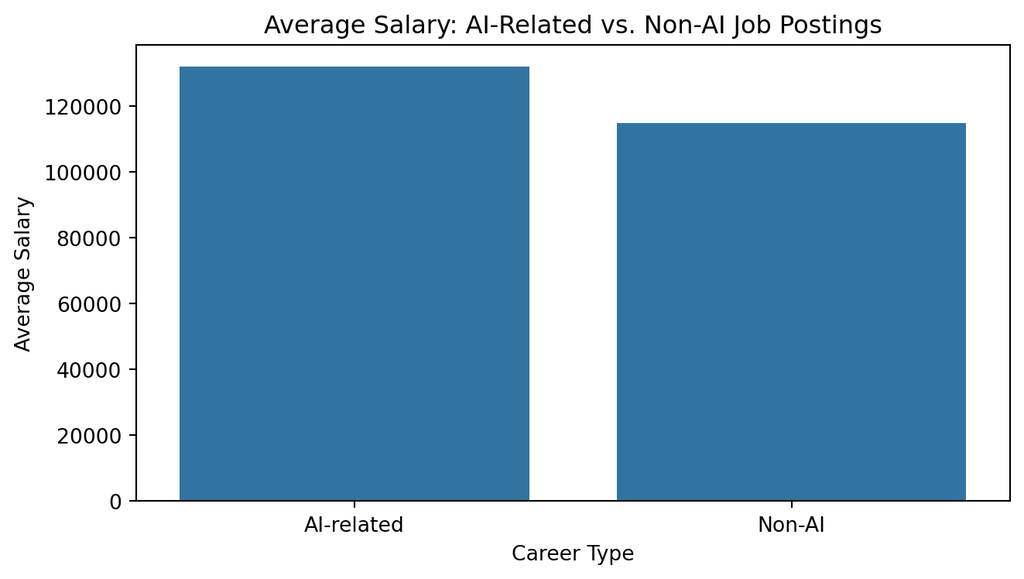

Figure 1: Average Salary: AI-Related vs. Non-AI Job Postings

```python
import seaborn as sns
import matplotlib.pyplot as plt

fig, ax = plt.subplots(figsize=(7, 4))

sns.barplot(
    data=ai_vs_non_ai_salary_pd,
    x="career_type",
    y="avg_salary",
    ax=ax
)

ax.set_title("Average Salary: AI-Related vs. Non-AI Job Postings")
ax.set_xlabel("Career Type")
ax.set_ylabel("Average Salary")

plt.tight_layout()
plt.show()
```

AI-related postings are identified using both Lightcast skill tags and AI-related keywords in job titles and descriptions. This combined classification reduces the chance of missing AI-related jobs that are not tagged with AI skills directly. The comparison uses only postings with valid salary values.